# multivariate_lin_regression

Jack Wright

11/11/2021

## Requirements for multivariate regression

```r
library(tidyverse)
library(here)
library(car)
library(ggResidpanel)
nyc<-read.csv(here('data','nyc.csv'))
```

Response Requirements 1.

`response!=binary & response!=count` IF `response==binary` use *multivariate_logistic_regression.Rmd* IF `response==count` use *multivariate_count_regression.Rmd*

High correlation between predictors can lead to unstable parameter estimates of regression which makes it very difficult to assess the effect of independent variables on dependent variables.

no autocorrelation if there is a time base ## Check distribution of response variable

-should be normal, transform if needed

check with car::powerTransform

```r
shapiro.test(nyc$Price)
```

```
##
##  Shapiro-Wilk normality test
##
## data:  nyc$Price
## W = 0.99223, p-value = 0.5031
```

H_0: data is normal

H_A: data is not normal

IF `shapiro.test(response)==FAIL` use `car::powerTransform(response)` to get transformation power

## Correlation and covariance

Dohoo et al. (1997) argued that multicollinearity is certain at the 0.9 level of a correlation coefficient or higher

## Analysis of Covariance and correlation

Correlation is a scaled form of covariance (the measure of change in one variable associated to change in another variable.) Types of covariance:

1. **coincident regression lines**
2. **parallel regression lines**

**regression lines with equal intercepts but different slopes**

**unrelated regression lines**

```r
library(dlookr)
```

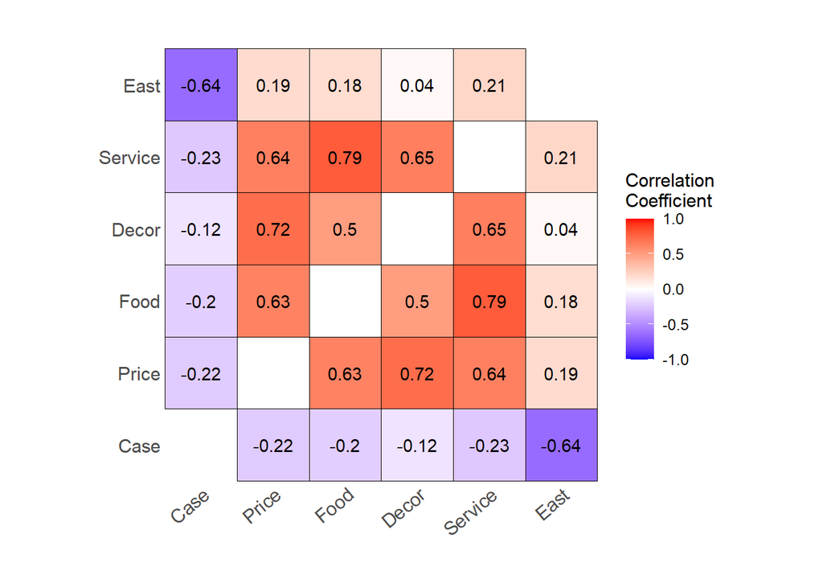

```r
dlookr::plot_correlate(nyc)
```

IF `correlation(x_i,x_j)>.9` consider dropping one of the variables from your analysis

## Create first fitted model

```r
library(tidyverse)
library(here)
nyc<-read.csv(here('data','nyc.csv'))%>%select(-c(Case,Restaurant))
```

```r
lm.list=list()
lm.list[["lm.base"]]<-lm(Price~.,data=nyc)
```

```r
summary(lm.list[["lm.base"]])
```

```
##
## Call:
## lm(formula = Price ~ ., data = nyc)
##
## Residuals:
##      Min       1Q   Median       3Q      Max
## -14.0465  -3.8837   0.0373   3.3942  17.7491
##
## Coefficients:
##               Estimate Std. Error t value Pr(>|t|)
## (Intercept) -24.023800   4.708359  -5.102 9.24e-07 ***
## Food          1.538120   0.368951   4.169 4.96e-05 ***
## Decor         1.910087   0.217005   8.802 1.87e-15 ***
## Service      -0.002727   0.396232  -0.007   0.9945
## East          2.068050   0.946739   2.184   0.0304 *
## ---
## Signif. codes:  0 '***' 0.001 '**' 0.01 '*' 0.05 '.' 0.1 ' ' 1
##
## Residual standard error: 5.738 on 163 degrees of freedom
## Multiple R-squared:  0.6279, Adjusted R-squared:  0.6187
## F-statistic: 68.76 on 4 and 163 DF,  p-value: < 2.2e-16
```

## Examine Residuals for possible transformations

see *transformations.Rmd* for interpretation of residual plots for transformations

```r
library(regclass)
regclass::VIF(lm.list[['lm.base']])
```

```
##     Food    Decor  Service     East
## 2.714261 1.744851 3.558735 1.064985
```

see *predictor_interaction.RMd*

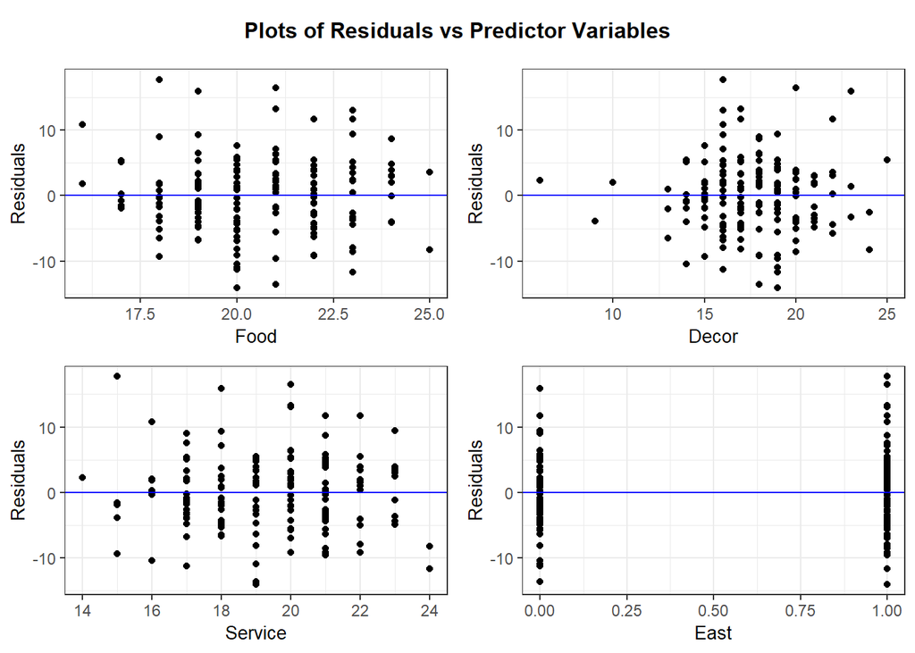

```r
ggResidpanel::resid_xpanel(lm.list[['lm.base']])
```

```r
car::powerTransform(nyc%>%select(-c(Price,East)))
```

```
## Estimated transformation parameters
##     Food    Decor  Service
## 0.748239 1.446262 1.729677
```

it looks like decor might be polynomial

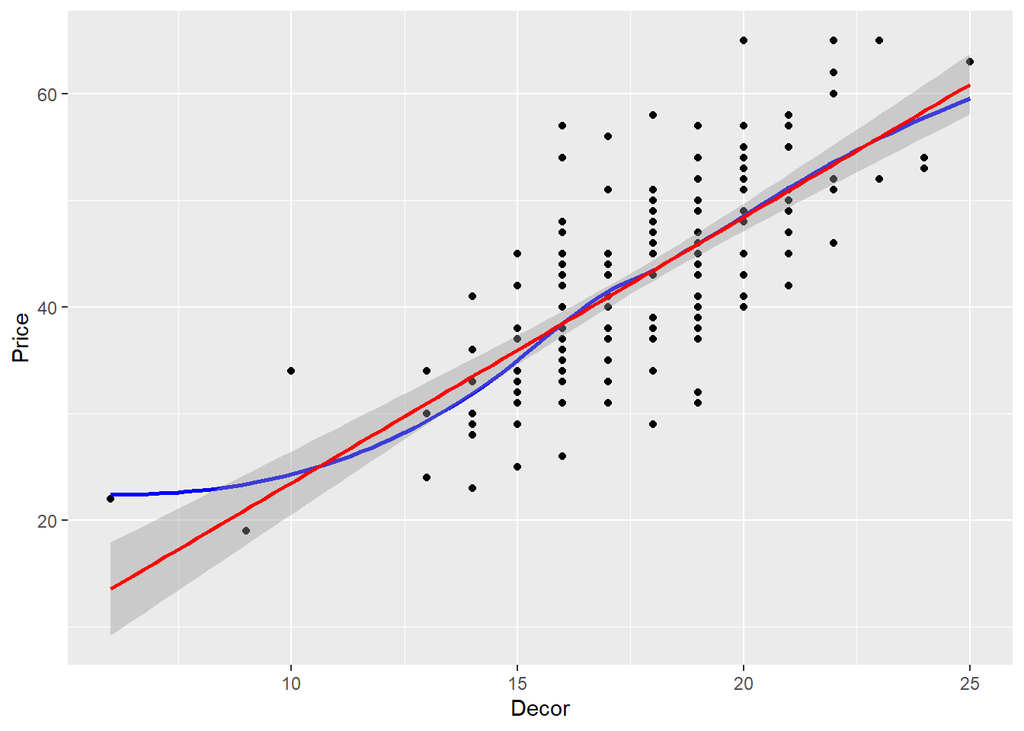

```r
ggplot(nyc,aes(x=Decor,y=Price))+geom_point()+geom_smooth(method='loess',se=FALSE,color='blue')+geom_smooth(method='lm',color='red')
```

## Check for heteroscedasticity

```r
library(lmtest)
lmtest::bptest(lm.list[['lm.base']])
```

```
##
##  studentized Breusch-Pagan test
##
## data:  lm.list[["lm.base"]]
## BP = 3.1186, df = 4, p-value = 0.5382
```

if `heteroscedasticity(model)==FAIL` SEE *heteroscedasticity_FAIL.Rmd*

## Examine interactions between predictor variables for possible transformations

**VIF**

-The VIF of a predictor is a measure for how easily it is predicted from a linear regression using the other predictors.

a VIF above 10 indicates high correlation and is cause for concern. Some authors suggest a more conservative level of 2.5 or above.

if `VIF(predictor)>threshold` best practice is to *remove* the predictors with the highest VIF and rerun the model.

```r
library(regclass)
regclass::VIF(lm.list[['lm.base']])
```

```
##     Food    Decor  Service     East
## 2.714261 1.744851 3.558735 1.064985
```

## Add transformations to base model

```r
lm.list[['lm.transform']]<-update(lm.list[['lm.base']],~.+I(Decor)^2)


#summary(lm.list[['lm.transform']])
```

## Create “best subsets” models

this will create give you the best possible model for models with n predictors up to the `nvmax` parameter

you can use the parameter `method` to select forward or backward selection methods

```r
library(leaps)
max_model_variable=4
best_subset<-leaps::regsubsets(Price~.,data=nyc,nvmax=max_model_variable)

results<-summary(best_subset)
```

## Extract and plot results from “lm.best_subset”

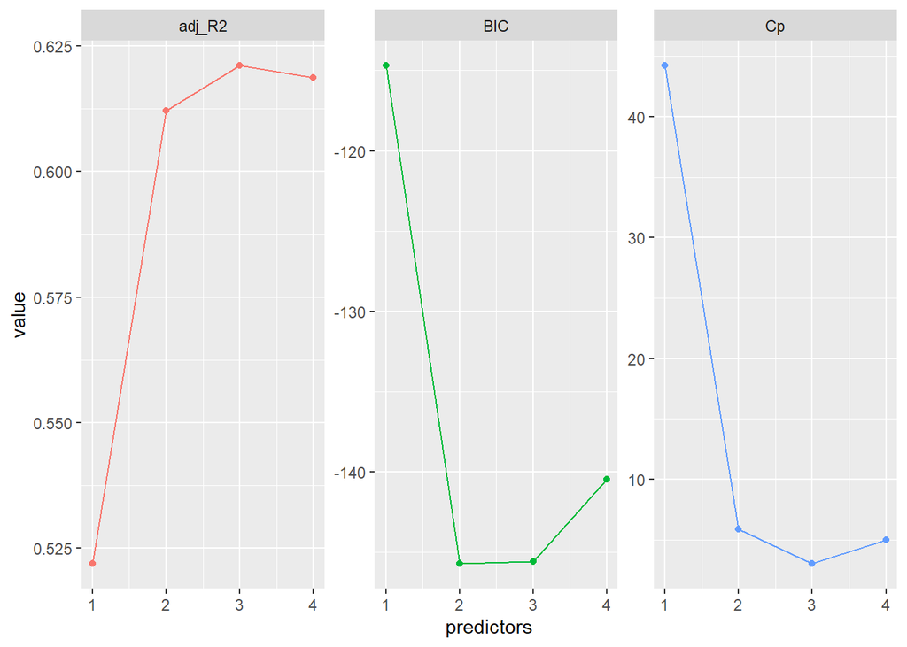

```r
tibble(predictors = 1:max_model_variable,
       adj_R2 = results$adjr2,
       Cp = results$cp,
       BIC = results$bic) %>%
  gather(statistic, value, -predictors) %>%
  ggplot(aes(predictors, value, color = statistic)) +
  geom_line(show.legend = F) +
  geom_point(show.legend = F) +
  facet_wrap(~ statistic, scales = "free")
```

```r
paste('best adjR2: ',which.max(results$adjr2),"best BIC: ",which.min(results$bic),"best Cp: ",which.min(results$bic))
```

[output not shown]

Decide which number of variables is best by examining the curves

## Compare variables and coefficients that these models include

```r
# 2 variable model

coef(best_subset,2)
```

```
## (Intercept)        Food       Decor
##  -24.500156    1.646149    1.882015
```

## Manually refit model with best predictors to model_list()

```r
lm.list[['lm.best']]<-lm(Price~Food+Decor,data=nyc)
```

## Model Diagnostics

F-test:

.05 threshold model is good

AIC and BIC, model with lowest is best

## VIF

-The VIF of a predictor is a measure for how easily it is predicted from a linear regression using the other predictors.

a VIF above 10 indicates high correlation and is cause for concern. Some authors suggest a more conservative level of 2.5 or above.

```r
library(regclass)
regclass::VIF(lm.list[['lm.base']])
```

```
##     Food    Decor  Service     East
## 2.714261 1.744851 3.558735 1.064985
```

## Model Selection

```r
AICs<-do.call(AIC,unname(lm.list))$AIC
adjr2<-lapply(X=lm.list,
       FUN=function(x) unlist(summary(x)$adj.r.squared))
(select_df<-data.frame(Models=names(lm.list),AIC=round(AICs,2), R2=round(unlist(unname(adjr2)),2)))
```

```
##         Models     AIC   R2
## 1      lm.base 1070.71 0.62
## 2 lm.transform 1070.71 0.62
## 3      lm.best 1071.68 0.61
```